# Project 03

Seth Harrison

Updated: Wednesday, December 12, 2018 @ 11:50:01 AM

```r
library(ggplot2)
library(dplyr)
fish <- read.csv("https://raw.githubusercontent.com/STAT-JET-ASU/Datasets/master/Chihara/FishMercury.csv")
```

### Your Analyses

1. Compute the sample size, mean, standard deviation, median, and 5% trimmed mean for the sample using `summarize` in `dplyr`. Create a boxplot using `ggplot2`. You do not need a title or different axis labels.

```r
FishSumm <- fish %>% summarize(n = n(),
                                   mean = mean(fish$Mercury),
                                   Stdv = sd(fish$Mercury),
                                   median = median(fish$Mercury),
                                   TrimMean = mean(fish$Mercury, trim = .05))
print(FishSumm)
```

```
   n      mean      Stdv median  TrimMean
1 30 0.1818667 0.3216053  0.129 0.1266786
```

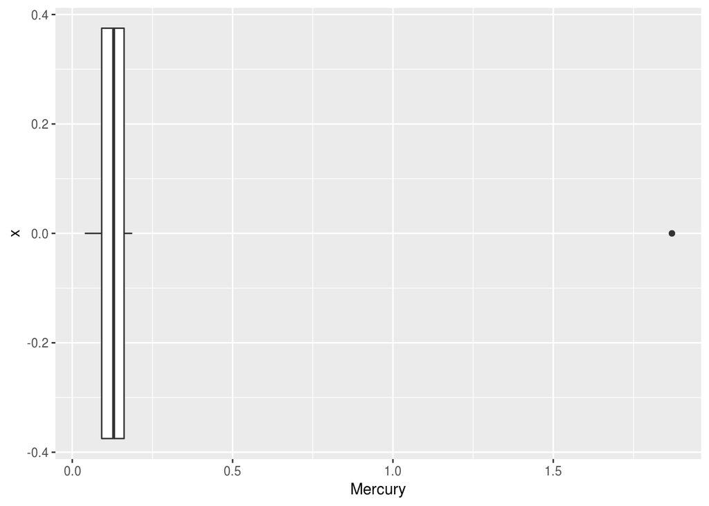

```r
ggplot(fish, aes(x = NULL, y = Mercury)) + geom_boxplot() + coord_flip()
```

2) A common rule for determining when we can use the central limit theorem is n ≥ 30. Since that is true in this instance, compute a traditional 95% confidence interval to estimate the true mean level of mercury for this species of fish in the sampled lake.

```r
fish <- read.csv("https://raw.githubusercontent.com/STAT-JET-ASU/Datasets/master/Chihara/FishMercury.csv") %>%
  filter(Mercury > 0)
Merc <- fish$Mercury
n      <- length(Merc)
mean(Merc) + qt(c(0.025, 0.975), n-1) * sd(Merc)/sqrt(n)
```

```
[1] 0.06177727 0.30195607
```

3. Compute a bootstrap 95% percentile interval to estimate the true mean level of mercury for this species of fish in the sampled lake. Do not include any plots in this section.

```r
N <- 10^4

bootmean <- numeric(N)

for (i in 1:N){
  bootsample <- sample(Merc, n, replace = TRUE)
  bootmean[i] <- mean(bootsample)
}

quantile(bootmean, c(0.025, 0.975))
```

```
     2.5%     97.5%
0.1124000 0.3081675
```

4. Assess your bootstrap sampling distribution of $\bar{x}$ for normality using a density plot, an ECDF plot, and a quantile-quantile plot. Include red reference curves for the theoretical normal distribution.

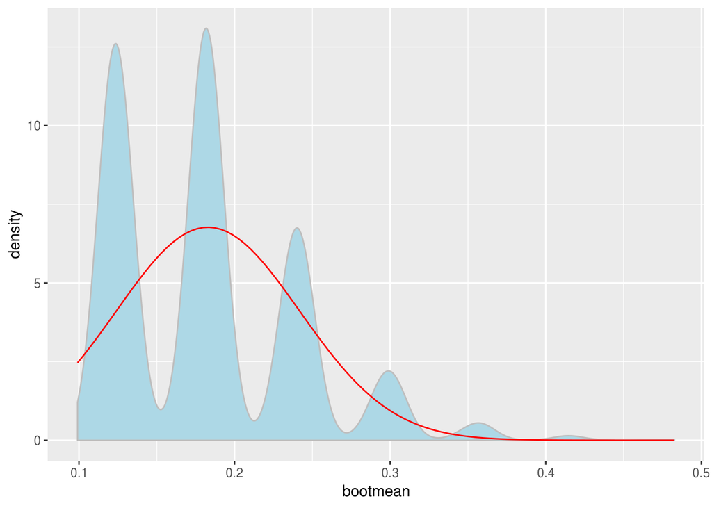

```r
ggplot(NULL, aes(x = bootmean)) +
  geom_density(fill = "lightblue", color = "gray") +
  stat_function(fun = dnorm, args = list(mean(bootmean), sd(bootmean)), color = "red")
```

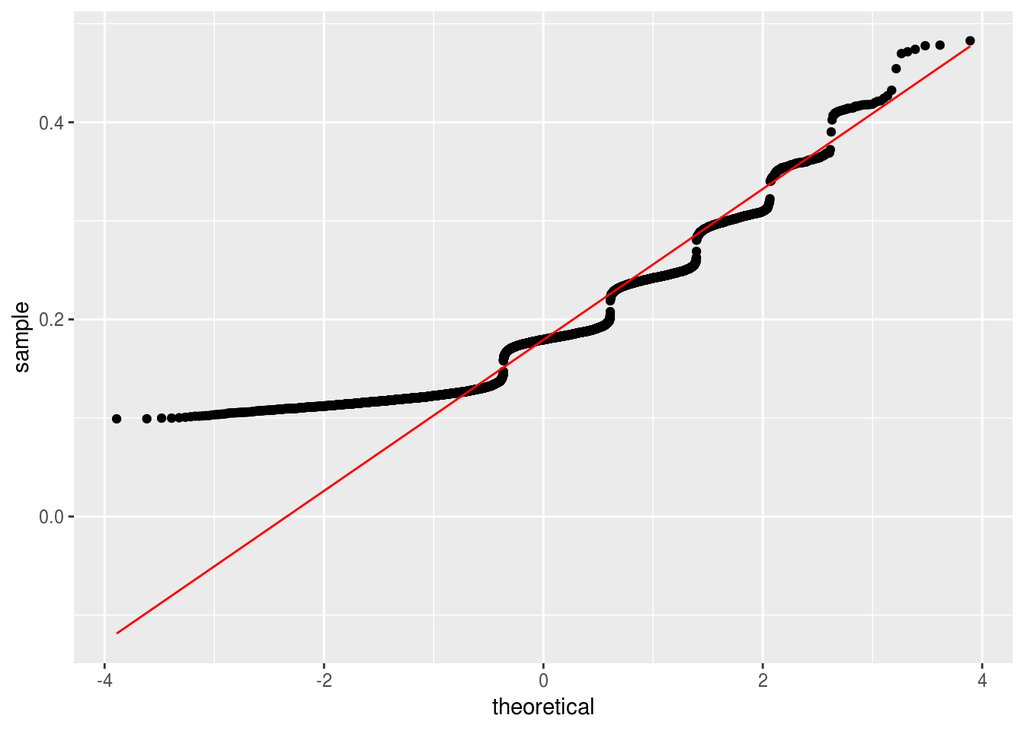

```r
ggplot(NULL, aes(sample = bootmean)) +
  geom_qq() +
  geom_qq_line(color = "red")
```

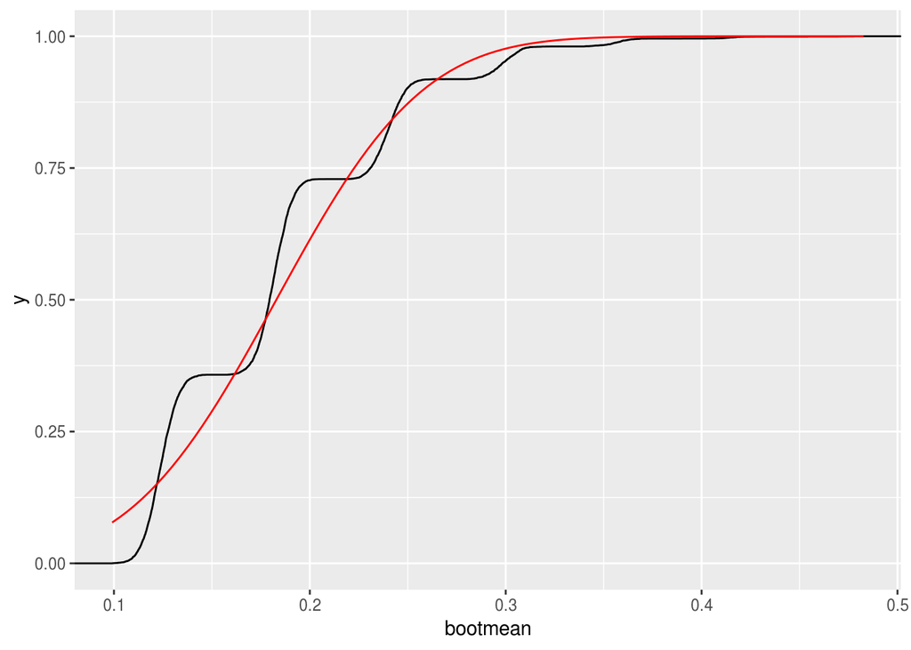

```r
M <- mean(bootmean)
S <- sd(bootmean)
ggplot(NULL, aes(x = bootmean)) +
  stat_ecdf() +
  stat_function(fun = pnorm, args = list(M, S), color = "red")
```

5. Create an ordered factor variable called `safety` that categorizes fish in the sample as “Best”, “Good”, or “Avoid”. Then create a barplot to display that variable. Include an informative title and axis labels.

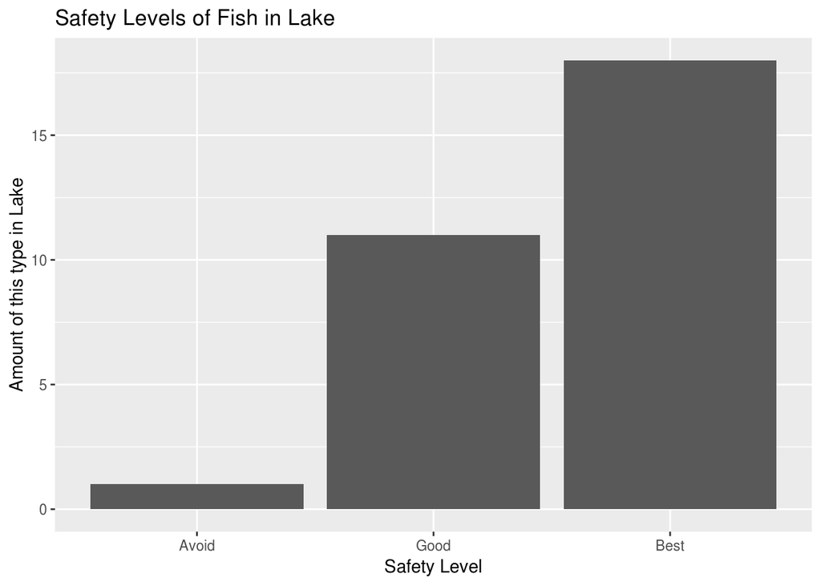

```r
safety <- fish %>% mutate(SafetyLevel = case_when(
  Mercury <= .15 ~ "Best",
  Mercury > .15 & Mercury <= .46 ~ "Good",
  Mercury > .46 ~ "Avoid"
))

safety$SafetyLevel<- factor(safety$SafetyLevel, levels = c("Avoid","Good","Best"))

ggplot(safety, aes(x = SafetyLevel)) + geom_bar() + labs(x = "Safety Level", y = "Amount of this type in Lake", title = "Safety Levels of Fish in Lake")
```

6. Compute a bootstrap 95% percentile interval to estimate the true proportion of this species of fish that fall into the “best” category. Do not include any plots in this section.

```r
N <- 10^4

bootmean <- numeric(N)

safetyBest <- safety$SafetyLevel == "Best"

for (i in 1:N){
  bootsampleBest <- sample(safetyBest, n, replace = TRUE)
  bootmean[i] <- mean(bootsampleBest)
}

quantile(bootmean, c(0.025, 0.975))
```

```
     2.5%     97.5%
0.4333333 0.7666667
```

7. Why are your intervals in (2) and (3) different? Is it appropriate to the CLT for these data? Expain using the results of (1) and (4).

8. Assuming this is a representative sample, can we confidently say a majority of all fish of this species in the lake have fewer than 0.15 µg/g of mercury? Why or why not?

ANSWER: No we can not say that a majority of all fish of this species in the lake have fewer than .15 ug/g of mercury because the confidence interval states that there is still a chance of having below 50% which is the .4333. Because of this chance we cannot say the majority of fish have under .15 µg/g of mercury.

END PROJECT 3